# This is assignment 9 - Thienkim Le

## Requirement 4

Explain how NumPy arrays are like Python lists and how they are different. See multiple chapters for this information.

```python
# Example 1: Creating NumPy arrays and Python lists

import numpy as np

# Creating a NumPy array
numpy_array = np.array([1, 2, 3, 4, 5])

# Creating a Python list
python_list = [1, 2, 3, 4, 5]

# Example 2: Accessing elements

# Accessing elements in a NumPy array
print("NumPy array:")
print(numpy_array[0])  # Output: 1
print(numpy_array[-1])  # Output: 5

# Accessing elements in a Python list
print("\nPython list:")
print(python_list[0])  # Output: 1
print(python_list[-1])  # Output: 5

# Example 3: Arithmetic operations

# Adding 1 to every element in the NumPy array
numpy_array_plus_one = numpy_array + 1
print("\nNumPy array after addition:")
print(numpy_array_plus_one)  # Output: [2 3 4 5 6]

# Adding 1 to every element in the Python list
python_list_plus_one = [x + 1 for x in python_list]
print("\nPython list after addition:")
print(python_list_plus_one)  # Output: [2, 3, 4, 5, 6]
```

```
NumPy array:
1
5

Python list:
1
5

NumPy array after addition:
[2 3 4 5 6]

Python list after addition:
[2, 3, 4, 5, 6]
```

## Requirement 5

Explain how variable typing is performed in Python compared to how it is performed in a language like C.

```python
# Example 1: Variable typing in Python

# Python is dynamically typed
x = 5  # x is an integer
print("x is of type:", type(x))  # Output: <class 'int'>

x = "Hello"  # x is now a string
print("x is of type:", type(x))  # Output: <class 'str'>
```

```
x is of type: <class 'int'>
x is of type: <class 'str'>
```

## Requirement 6

Explain how integer storage is performed in Python compared to how it is performed in a language like C.

In Python, integer storage is performed dynamically, and integers are stored as variable-length objects. Python integers can grow to accommodate arbitrarily large values without causing overflow errors. Python's interpreter handles the memory management and allocation for integer objects, which allows for flexibility but may result in slightly slower performance compared to fixed-size integer storage.

```python
x = 123456789012345678901234567890  # Large integer value
```

In contrast, in a language like C, integer storage is performed statically, and integers are typically stored using fixed-size memory allocations, such as 2 bytes (short int), 4 bytes (int), or 8 bytes (long int), depending on the platform and compiler. This fixed-size storage allows for faster arithmetic operations but limits the range of values that integers can represent without causing overflow errors.

```python
int x = 123;  // Integer value stored in a fixed-size memory allocation
```

```
  Cell In[14], line 1
    int x = 123;  // Integer value stored in a fixed-size memory allocation
        ^
SyntaxError: invalid syntax
```

To ensure that the integer value is stored correctly in C, we can use a data type that can accommodate the given value. In this case, we can use the long long data type, which typically provides at least 64 bits of storage, allowing it to hold larger integer values without overflow. Here's the corrected version in C:

```python
#include <stdio.h>
#include <stdlib.h>

int main() {
    const char *value = "1234567890123456789";
    unsigned long long x = strtoull(value, NULL, 10);  // Convert string to unsigned long long
    printf("%llu\n", x);
    return 0;
}
```

```
  Cell In[16], line 4
    int main() {
        ^
SyntaxError: invalid syntax
```

```python
!g++ largeInteger.cpp
```

```python
!./largeInteger.exe
```

```
'.' is not recognized as an internal or external command,
operable program or batch file.
```

## Requirement 7

Create a list (L1) of numbers 1-20. Convert the numbers in L1 to strings and store them in a new list (L2).

```python
# Create a list of numbers 1-20
L1 = list(range(1, 21))

# Convert numbers in L1 to strings and store them in L2
L2 = [str(num) for num in L1]

# Print both lists to verify
print("L1 (numbers 1-20):", L1)
print("L2 (converted to strings):", L2)
```

```
L1 (numbers 1-20): [1, 2, 3, 4, 5, 6, 7, 8, 9, 10, 11, 12, 13, 14, 15, 16, 17, 18, 19, 20]
L2 (converted to strings): ['1', '2', '3', '4', '5', '6', '7', '8', '9', '10', '11', '12', '13', '14', '15', '16', '17', '18', '19', '20']
```

## Requirement 8

Demonstrate a heterogeneous list with at least 5 different data types.

```python
heterogeneous_list = ["Hello", 42, 3.14, True, [1, 2, 3]]

# Print the list and its types
for item in heterogeneous_list:
    print(f"{item} - Type: {type(item)}")
```

```
Hello - Type: <class 'str'>
42 - Type: <class 'int'>
3.14 - Type: <class 'float'>
True - Type: <class 'bool'>
[1, 2, 3] - Type: <class 'list'>
```

## Requirement 9

Create a Python array using the built-in array module. Demonstrate the following operations on the array:

- append
- insert
- index
- attempt to insert an element of a different type

```python
from array import array

# Create an array of integers (type 'i')
arr = array('i', [1, 2, 3, 4, 5])

# Append operation
arr.append(6)
print("After appending 6:", arr)

# Insert operation
arr.insert(2, 10)  # Insert 10 at index 2
print("After inserting 10 at index 2:", arr)

# Index operation
index_of_3 = arr.index(3)
print("Index of 3:", index_of_3)

# Attempt to insert an element of a different type
try:
    arr.insert(2, 'a')  # Attempt to insert a character into an array of integers
except TypeError as e:
    print("Error:", e)

# Printing the array after the unsuccessful attempt
print("Array after unsuccessful attempt:", arr)
```

```
After appending 6: array('i', [1, 2, 3, 4, 5, 6])
After inserting 10 at index 2: array('i', [1, 2, 10, 3, 4, 5, 6])
Index of 3: 3
Error: 'str' object cannot be interpreted as an integer
Array after unsuccessful attempt: array('i', [1, 2, 10, 3, 4, 5, 6])
```

## Requirement 10

Create a NumPy array of 10 floats named one_d_array. Demonstrate the following operations on the array:

- implicit casting (the author calls this up-casting)
- explicit casting

```python
import numpy as np

# Create a NumPy array of 10 floats
one_d_array = np.array([1.1, 2.2, 3.3, 4.4, 5.5, 6.6, 7.7, 8.8, 9.9, 10.0], dtype=float)

# Implicit casting (up-casting)
# Performing an operation that requires a wider data type will automatically up-cast the array
# For example, adding an integer to the array of floats
result_implicit = one_d_array + 5

# Explicit casting
# Converting the array to integers using astype()
one_d_array_int = one_d_array.astype(int)

# Print original array and results
print("Original array of floats:")
print(one_d_array)
print("\nResult of implicit casting (up-casting):")
print(result_implicit)
print("\nArray after explicit casting to integers:")
print(one_d_array_int)
```

```
Original array of floats:
[ 1.1  2.2  3.3  4.4  5.5  6.6  7.7  8.8  9.9 10. ]

Result of implicit casting (up-casting):
[ 6.1  7.2  8.3  9.4 10.5 11.6 12.7 13.8 14.9 15. ]

Array after explicit casting to integers:
[ 1  2  3  4  5  6  7  8  9 10]
```

## Requirement 11

Use list comprehension to create a two-dimensional NumPy array named two_d_array with 5 rows and 3 columns with the following content:

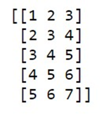

```python
import numpy as np

two_d_array = np.array([[i+j for j in range(3)] for i in range(1,6)])
print(two_d_array)
```

```
[[1 2 3]
 [2 3 4]
 [3 4 5]
 [4 5 6]
 [5 6 7]]
```

## Requirement 12

Create a 3-dimensional NumPy array named three_d_array with random numbers between 0-99. The shape of the array should be (3, 5, 5). Also display the size in bytes of the array.

```python
import numpy as np

# Create a 3-dimensional NumPy array with random numbers between 0 and 99
three_d_array = np.random.randint(0, 100, size=(3, 5, 5))

# Display the array
print("3-dimensional NumPy array:")
print(three_d_array)

# Display the size in bytes of the array
print("\nSize of the array in bytes:", three_d_array.nbytes)
```

```
3-dimensional NumPy array:
[[[95 87 33 62 98]
  [55 56 78 51  4]
  [95  9 95 95 15]
  [74 83 28 39 52]
  [65 76 10 40 24]]

 [[33 94 62  8 26]
  [80 34  0 40 68]
  [68 28 29 56 98]
  [83 10 32 31 74]
  [88 65 99 53 67]]

 [[25 89 92 54 59]
  [19  4 90 71 45]
  [88 32 89 45 38]
  [ 1 23 86 13 81]
  [34 33 24 29 56]]]

Size of the array in bytes: 300
```

## Requirement 13

Demonstrate accessing 4 different individual elements of the three_d_array.

```python
import numpy as np

# Create a 3-dimensional NumPy array with random numbers between 0 and 99
three_d_array = np.random.randint(0, 100, size=(3, 5, 5))

# Accessing individual elements
# Accessing element at index (0, 0, 0)
element_1 = three_d_array[0, 0, 0]
# Accessing element at index (1, 2, 3)
element_2 = three_d_array[1, 2, 3]
# Accessing element at index (2, 3, 1)
element_3 = three_d_array[2, 3, 1]
# Accessing element at index (0, 4, 2)
element_4 = three_d_array[0, 4, 2]

# Display the accessed elements
print("Element at index (0, 0, 0):", element_1)
print("Element at index (1, 2, 3):", element_2)
print("Element at index (2, 3, 1):", element_3)
print("Element at index (0, 4, 2):", element_4)
```

```
Element at index (0, 0, 0): 25
Element at index (1, 2, 3): 48
Element at index (2, 3, 1): 72
Element at index (0, 4, 2): 3
```

## Requirement 14

Demonstrate modifying 4 different individual elements of the three_d_array.

```python
import numpy as np

# Create a 3-dimensional NumPy array with random numbers between 0 and 99
three_d_array = np.random.randint(0, 100, size=(3, 5, 5))

# Display the original array
print("Original 3-dimensional array:")
print(three_d_array)

# Modify individual elements
# Modifying element at index (0, 0, 0)
three_d_array[0, 0, 0] = 100
# Modifying element at index (1, 2, 3)
three_d_array[1, 2, 3] = 200
# Modifying element at index (2, 3, 1)
three_d_array[2, 3, 1] = 300
# Modifying element at index (0, 4, 2)
three_d_array[0, 4, 2] = 400

# Display the modified array
print("\nModified 3-dimensional array:")
print(three_d_array)
```

```
Original 3-dimensional array:
[[[11 84 79 99 69]
  [29 59 94 78 80]
  [ 9 50 86 74 54]
  [96 44  1 43 68]
  [55 39  4 47 96]]

 [[23 72 56 12 92]
  [60 64 91 40 77]
  [35 58  8 68  7]
  [52 71 79 72 98]
  [58 43 67 73 53]]

 [[49 22 78 98 24]
  [89 76  0 71 85]
  [69 72 82 35 69]
  [45 63  1 50 59]
  [80 22 27 88 96]]]

Modified 3-dimensional array:
[[[100  84  79  99  69]
  [ 29  59  94  78  80]
  [  9  50  86  74  54]
  [ 96  44   1  43  68]
  [ 55  39 400  47  96]]

 [[ 23  72  56  12  92]
  [ 60  64  91  40  77]
  [ 35  58   8 200   7]
  [ 52  71  79  72  98]
  [ 58  43  67  73  53]]

 [[ 49  22  78  98  24]
  [ 89  76   0  71  85]
  [ 69  72  82  35  69]
  [ 45 300   1  50  59]
  [ 80  22  27  88  96]]]
```

## Requirement 15

Using one_d_array, demonstrate slicing:

- the first 7 elements
- all after index 7
- from index 3 to index 8
- every other element
- elements reversed
- reverse every other element from index 7

```python
import numpy as np

# Create a 1-dimensional NumPy array
one_d_array = np.array([1, 2, 3, 4, 5, 6, 7, 8, 9, 10])

# Slicing: the first 7 elements
sliced_1 = one_d_array[:7]

# Slicing: all after index 7
sliced_2 = one_d_array[7:]

# Slicing: from index 3 to index 8
sliced_3 = one_d_array[3:9]

# Slicing: every other element
sliced_4 = one_d_array[::2]

# Slicing: elements reversed
sliced_5 = one_d_array[::-1]

# Slicing: reverse every other element from index 7
sliced_6 = np.concatenate((one_d_array[:7], one_d_array[7:][::-1]))

# Displaying sliced arrays
print("Original array:", one_d_array)
print("\nSliced - first 7 elements:", sliced_1)
print("Sliced - all after index 7:", sliced_2)
print("Sliced - from index 3 to index 8:", sliced_3)
print("Sliced - every other element:", sliced_4)
print("Sliced - elements reversed:", sliced_5)
print("Sliced - reverse every other element from index 7:", sliced_6)
```

[output not shown]

## Requirement 16

Using two_d_array, demonstrate slicing:

- first 2 rows and first 2 columns
- all rows and every other column
- all columns and every other row
- extracting a subarray

```python
import numpy as np

# Create a 2-dimensional NumPy array
two_d_array = np.array([[1, 2, 3, 4, 5],
                         [6, 7, 8, 9, 10],
                         [11, 12, 13, 14, 15],
                         [16, 17, 18, 19, 20],
                         [21, 22, 23, 24, 25]])

# Slicing: first 2 rows and first 2 columns
sliced_1 = two_d_array[:2, :2]

# Slicing: all rows and every other column
sliced_2 = two_d_array[:, ::2]

# Slicing: all columns and every other row
sliced_3 = two_d_array[::2, :]

# Slicing: extracting a subarray
subarray = two_d_array[1:4, 1:4]

# Displaying sliced arrays
print("Original 2-dimensional array:")
print(two_d_array)

print("\nSliced - first 2 rows and first 2 columns:")
print(sliced_1)

print("\nSliced - all rows and every other column:")
print(sliced_2)

print("\nSliced - all columns and every other row:")
print(sliced_3)

print("\nExtracted subarray:")
print(subarray)
```

```
Original 2-dimensional array:
[[ 1  2  3  4  5]
 [ 6  7  8  9 10]
 [11 12 13 14 15]
 [16 17 18 19 20]
 [21 22 23 24 25]]

Sliced - first 2 rows and first 2 columns:
[[1 2]
 [6 7]]

Sliced - all rows and every other column:
[[ 1  3  5]
 [ 6  8 10]
 [11 13 15]
 [16 18 20]
 [21 23 25]]

Sliced - all columns and every other row:
[[ 1  2  3  4  5]
 [11 12 13 14 15]
 [21 22 23 24 25]]

Extracted subarray:
[[ 7  8  9]
 [12 13 14]
 [17 18 19]]
```

## Requirement 17

```python
import numpy as np

# Create a 1D array with values from 1 to 100
arr_1d = np.arange(1, 101)
print("The original array: \n",arr_1d)

# Reshape the 1D array into a 10x10 array
arr_2d = arr_1d.reshape(10, 10)
print("The 10x10 array: \n",arr_2d)
```

[output not shown]

## Requirement 18

Using one_d_array, create a row vector and a column vector.

```python
import numpy as np

# Create a 1-dimensional NumPy array
one_d_array = np.array([1, 2, 3, 4, 5])

# Create a row vector
row_vector = one_d_array.reshape(1, -1)  # Reshape to have 1 row and as many columns as needed (-1)

# Create a column vector
column_vector = one_d_array.reshape(-1, 1)  # Reshape to have as many rows as needed (-1) and 1 column

# Display the row vector and column vector
print("Original 1-dimensional array:")
print(one_d_array)

print("\nRow vector:")
print(row_vector)

print("\nColumn vector:")
print(column_vector)
```

[output not shown]

## Requirement 19

Explain what a NumPy universal function is and why they are useful.

A NumPy universal function (ufunc) is a function that operates element-wise on NumPy arrays. These functions are called "universal" because they can apply to arrays of any size and shape, broadcasting the operation if necessary. Ufuncs include basic arithmetic operations (addition, subtraction, multiplication, division), trigonometric functions, exponential and logarithmic functions, comparison functions, and more.

Here are some key characteristics and reasons why NumPy ufuncs are useful:

- Element-wise Operations: Ufuncs perform operations on each element of the array individually, which makes them highly efficient when working with large arrays. This allows for concise and readable code when applying operations to arrays.
- Broadcasting: Ufuncs automatically handle broadcasting, which means they can operate on arrays of different shapes and sizes. This simplifies operations where arrays may have different dimensions, making the code more versatile and easier to write.
- Vectorized Operations: Ufuncs are implemented in compiled C code, which makes them much faster compared to equivalent operations performed using Python loops. This vectorized operation significantly improves performance, especially when dealing with large datasets.
- Interoperability: Ufuncs seamlessly integrate with other NumPy functions and operations, as well as with libraries such as SciPy and pandas. This interoperability allows for complex computations and data manipulations to be performed efficiently.
- Standardization: NumPy ufuncs provide a standardized interface for common mathematical operations, ensuring consistency across different functions and operations. This standardization simplifies code maintenance and improves code readability.

Overall, NumPy universal functions are fundamental to the functionality and efficiency of NumPy arrays. They enable fast and efficient element-wise operations on arrays of any size and shape, making NumPy a powerful tool for numerical computing and data analysis in Python.

## Requirement 20

Demonstrate the use of the out argument.

```python
import numpy as np

# Create two input arrays
x = np.array([1, 2, 3, 4])
y = np.array([5, 6, 7, 8])

# Create an empty array to store the result
result = np.empty_like(x)

# Add the elements of x and y and store the result in the 'result' array
np.add(x, y, out=result)

# Display the result
print("Result of addition:", result)
```

```
Result of addition: [ 6  8 10 12]
```

## Requirement 21

Use aggregates to show the product of all elements of one_d_array.

```python
import numpy as np

# Create a 1-dimensional NumPy array
one_d_array = np.array([1, 2, 3, 4, 5])

# Calculate the product of all elements
product = np.prod(one_d_array)

# Display the result
print("Product of all elements in one_d_array:", product)
```

```
Product of all elements in one_d_array: 120
```

## Requirement 22

```python
import numpy as np

# Create NumPy arrays x and y
x = np.array([1, 2, 3, 4, 5])
y = np.array([2, 2, 2, 2, 2 ])

# Use the multiply() method to compute element-wise multiplication
result_multiply = np.multiply(x[:, np.newaxis], y)

# Use the outer() method to compute the outer product
result_outer = np.outer(x, y)

# Display the results
print("x = ", x)
print("\ny = ", y)
print("\narray (",result_outer,")")
```

```
x =  [1 2 3 4 5]

y =  [2 2 2 2 2]

array ( [[ 2  2  2  2  2]
 [ 4  4  4  4  4]
 [ 6  6  6  6  6]
 [ 8  8  8  8  8]
 [10 10 10 10 10]] )
```

## Requirement 23

Demonstrate NumPy’s sum, min, and max functions. Use the %timeit magic function to compare the performance to Python’s built-in sum, min, and max functions.

```python
import numpy as np

# Define a NumPy array
arr = np.random.randint(0, 5, size=10)  # Creating a large array of random integers
# NumPy functions
print("NumPy functions:")
%timeit np_sum = np.sum(arr)
%timeit np_min = np.min(arr)
%timeit np_max = np.max(arr)

# Python's built-in functions
print("\nPython's built-in functions:")
%timeit py_sum = sum(arr)
%timeit py_min = min(arr)
%timeit py_max = max(arr)
```

```
NumPy functions:
4.16 µs ± 80.8 ns per loop (mean ± std. dev. of 7 runs, 100,000 loops each)
4.11 µs ± 69.9 ns per loop (mean ± std. dev. of 7 runs, 100,000 loops each)
4.2 µs ± 254 ns per loop (mean ± std. dev. of 7 runs, 100,000 loops each)

Python's built-in functions:
1.32 µs ± 14.4 ns per loop (mean ± std. dev. of 7 runs, 1,000,000 loops each)
1.26 µs ± 54.2 ns per loop (mean ± std. dev. of 7 runs, 1,000,000 loops each)
1.31 µs ± 43.1 ns per loop (mean ± std. dev. of 7 runs, 1,000,000 loops each)
```

## Requirement 24

Use the file president_heights.csv to produce a histogram of U.S. President height information.

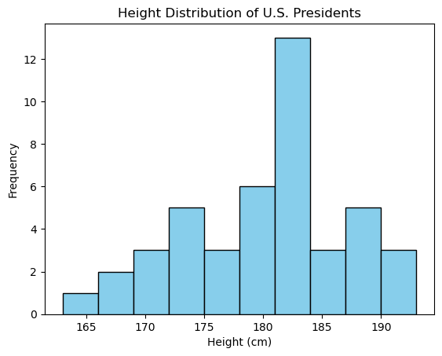

```python
import pandas as pd
import matplotlib.pyplot as plt

# Load the data from the CSV file into a DataFrame
data = pd.read_csv(r'c:\Users\lethi\President_Heights.csv')

# Extract the heights from the DataFrame
heights = data['height(cm)']

# Create a histogram
plt.hist(heights, bins=10, color='skyblue', edgecolor='black')

# Add labels and title
plt.xlabel('Height (cm)')
plt.ylabel('Frequency')
plt.title('Height Distribution of U.S. Presidents')

# Show the plot
plt.show()
```

## Requirement 25

Use broadcasting and Matplotlib to plot produce a plot of a twodimensional array

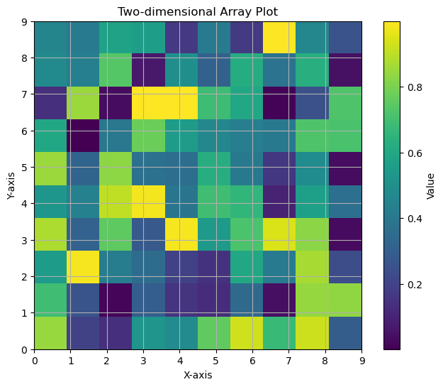

```python
import numpy as np
import matplotlib.pyplot as plt

# Create a two-dimensional array
array_2d = np.random.rand(10, 10)  # Example 10x10 random array

# Create meshgrid coordinates using broadcasting
x = np.arange(array_2d.shape[0])[:, np.newaxis]
y = np.arange(array_2d.shape[1])[np.newaxis, :]

# Plot the array using Matplotlib
plt.figure(figsize=(8, 6))
plt.imshow(array_2d, cmap='viridis', origin='lower', extent=(x.min(), x.max(), y.min(), y.max()))
plt.colorbar(label='Value')
plt.title('Two-dimensional Array Plot')
plt.xlabel('X-axis')
plt.ylabel('Y-axis')
plt.grid(True)
plt.show()
```

## Requirement 26

Use markdown to include a statement at the end of assignment-09.ipynb explaining your experiences with Assignment 09. Make this authentic (minimum of 2-3 sentences).

## Reflection on Assignment 09

Working on Assignment 09 was both challenging and rewarding. I enjoyed diving deeper into the concepts of NumPy arrays, broadcasting, and universal functions. However, I found the task of optimizing performance using NumPy functions and comparing them to Python's built-in functions to be particularly challenging. Overall, this assignment provided valuable insights into the power and versatility of NumPy for efficient numerical computing in Python.